# Limpeza de Dados para Séries Temporaias

```r
# Importando libs
require(zoo, quietly = TRUE)
require(data.table, quietly = TRUE)
```

# Limpe seu dados

## Lidando com dados ausentes

Os dados ausentes são ainda mais comuns na análise de séries temporais do que na análise de dados transversais, por que a carga da amostragem longitudinaç é bastante pesada:

- Séries temporais incompletas são batantes comuns

Métodos para lidar com dados ausentes mais comuns são:

1. imputação
2. interpolação
3. Exclusão dos periodos de tempos afetados

### Preparando um conj. dados para testar metodologias de imputação

```r
path = 'C:\\Users\\mateu\\Documents\\MEGA\\Projetos-git\\analise-pratica-series-temporais_predicao-stats-ml\\Capitulo_2 - Data Wrangling\\datasets\\UNRATE.csv'

unemp = fread(input = path, sep = ',')

head(x = unemp, n = 5)
```

| DATE | UNRATE |
| --- | --- |
| 1948-01-01 | 3.4 |
| 1948-02-01 | 3.8 |
| 1948-03-01 | 4.0 |
| 1948-04-01 | 3.9 |
| 1948-05-01 | 3.5 |

```r
# Convertendo para date
unemp[, DATE := as.Date(DATE)]
```

```r
# definindo o index
setkey(unemp, DATE)
```

```r
head(x = unemp, n = 4)
```

| DATE | UNRATE |
| --- | --- |
| 1948-01-01 | 3.4 |
| 1948-02-01 | 3.8 |
| 1948-03-01 | 4.0 |
| 1948-04-01 | 3.9 |

Gerando um conj. de dados onde os dados estão aleatoriamente ausentes.

```r
set.seed(10)
rand.unemp.idx = sample(1:nrow(unemp), .1*nrow(unemp))

rand.unemp = unemp[-rand.unemp.idx]
```

```r
high.unemp.idx = which(unemp$DATE > 8)
num.to.select  = .2 * length(high.unemp.idx)

high.unemp.idx = sample(high.unemp.idx, )
bias.unemp = unemp[-high.unemp.idx]
```

Como excluimos as linhas da nossa tabela de dados para criar um conj. de dados com dados ausentes, precisamos ler as datas ausentes e o valores NA.

```r
todas.datas = seq(
  from = unemp$DATE[1], to = tail(unemp$DATE, 1),
  by = "months"
)
todas.datas[1:4]
```

```
[1] "1948-01-01" "1948-02-01" "1948-03-01" "1948-04-01"
```

```r
rand.unemp = rand.unemp[J(todas.datas), roll = 0]
bias.unemp = bias.unemp[J(todas.datas), roll = 0]
```

```r
rand.unemp[, rtp := is.na(UNRATE)]
```

```r
head(
  x = rand.unemp[rtp == TRUE], n = 3
)
```

| DATE | UNRATE | rtp |
| --- | --- | --- |
| 1949-01-01 | NA | TRUE |
| 1950-02-01 | NA | TRUE |
| 1950-09-01 | NA | TRUE |

#### Forward Fill

```r
na.locf(coluna, na.rm = FALSE)
```

Imputando no R :

```r
# Para aleatorio
rand.unemp[, impute.ff := na.locf(UNRATE, na.rm = FALSE)]

# Para o com maior prob. de desemprego
bias.unemp[, impute.ff := na.locf(UNRATE, na.rm = FALSE)]
```

Plotando

```r
# plot de um gráfico de amostra que mostra as partes achatadas

unemp[
  350:400,
  plot(DATE, UNRATE, col = 1, lwd = 2, type = 'b')
]
```

```r
rand.unemp[
  350:400,
  lines(
    DATE, impute.ff, col = 2, lwd = 2, lty = 2
  )
]
```

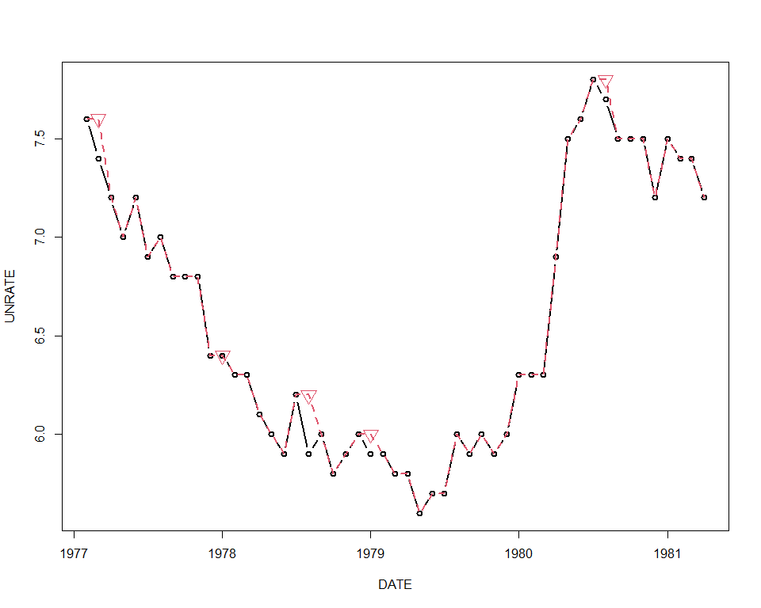

```r
rand.unemp[350:400][rtp == TRUE,
                    points(
                      DATE, impute.ff,
                      col = 2, pch = 6, cex = 2
                    )]
```

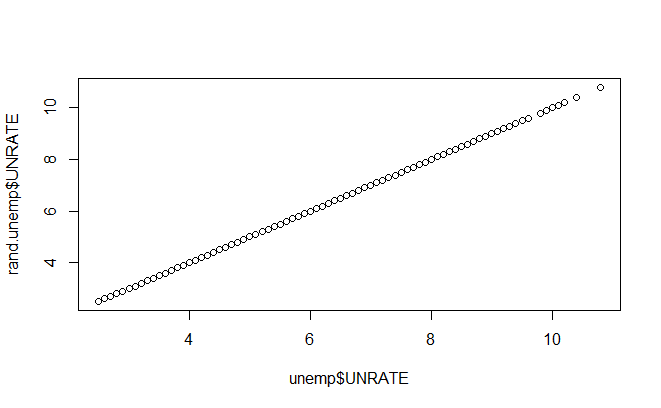

```r
plot(
  unemp$UNRATE, rand.unemp$UNRATE
)
```

Pode imputar os valor de trás para frente , contudo, se quiser treinar um modelo isso trata de um lookhead.

> Em alguns forward fill é melhor maneira de preencher valores ausentes, mesmo que métodos “mais sofisticados” sejam possíveis.
> - Não é exigente em termos computacionais, pode ser facilmente aplicados a dados em tempo real.

#### Média Móvel

Semelhante ao forward fill mas imputa dados com uma média model ou mediana. Voce usa entradas provenientes de multiplos tempos recentes no passado.

Situaçõess em que a média móvel melhor se adéqua á tarefa em questão do que um forward fill :

1. Se os dados forem ruidosos e voce tem razões para duvidar do valor de qualquer ponto de dados individual em relação a um média geral, recomenda-se usar uma média móvel.
   - Forward Fill pode incluir mais ruídos aleatório do que a métrica “verdadeira” que lhe interessa. Média movel pode remover parte desse ruído.

```r
rand.unemp[,
           impute.rm.nolookahead := rollapply(
             c(NA, NA, UNRATE), 3,
                function(x){
                  if (!is.na(x[3])) x[3] else mean(x, na.rm = TRUE)
                }
           )]
```

```r
bias.unemp[,
           impute.rm.nolookahead := rollapply(
             c(NA, NA, UNRATE), 3,
                function(x){
                  if (!is.na(x[3])) x[3] else mean(x, na.rm = TRUE)
                }
           )]
```

```r
# plot de um gráfico de amostra que mostra as partes achatadas

unemp[
  350:400,
  plot(DATE, UNRATE, col = 1, lwd = 2, type = 'b')
]
```

```r
rand.unemp[
  350:400,
  lines(
    DATE, impute.rm.nolookahead, col = 2, lwd = 2, lty = 2
  )
]
```

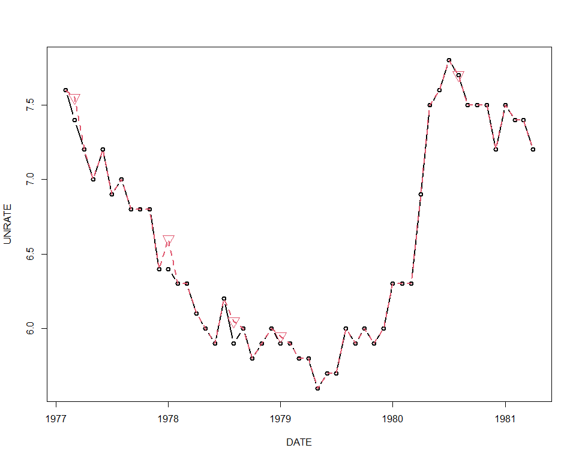

```r
rand.unemp[350:400][rtp == TRUE,
                    points(
                      DATE, impute.rm.nolookahead,
                      col = 2, pch = 6, cex = 2
                    )]
```

Exemplo real do rollapply:

```r
a = rollapply( c(NA, NA, c(1 , 2, NA, NA, 1, 2, 2, NA, 10) ), 3,
                function(x){
                  if (!is.na(x[3])) x[3] else mean(x, na.rm = TRUE) }
           )
a
```

```
[1]  1.0  2.0  1.5  2.0  1.0  2.0  2.0  2.0 10.0
```

Retornando….

Caso não esteja preocupado em fornecer seus dados a um modelo e se sente a vontade de construir um lookahead. Pode usar a media movel incluindo dados do passado e futuro.

```r
rand.unemp[,
           complete.rm := rollapply(
             c(NA, UNRATE, NA), 3,
             function(x){
               if (!is.na(x[2])) x[2]
               else mean(x, na.rm = TRUE)
             }
           )
           ]
```

```r
# plot de um gráfico de amostra que mostra as partes achatadas

unemp[
  350:400,
  plot(DATE, UNRATE, col = 1, lwd = 2, type = 'b')
]
```

```r
rand.unemp[
  350:400,
  lines(
    DATE, complete.rm, col = 2, lwd = 2, lty = 2
  )
]
```

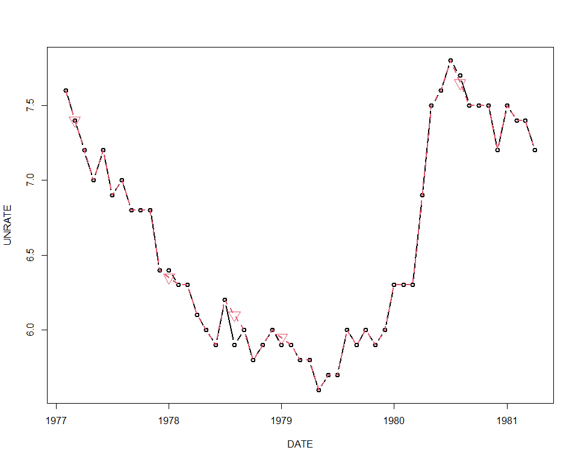

```r
rand.unemp[350:400][rtp == TRUE,
                    points(
                      DATE, complete.rm,
                      col = 2, pch = 6, cex = 2
                    )]
```

Usar a média movel, **reduz a variancia** no conj. de dados.

#### Interpolação

Usa para determinar dados de valores ausentes com base em restrições geometricas sobre como queremos que os dados gerais se comportem.

Pode ser feito semelhante a média movel se quiser imputar valores com base em valores passados e futuros(Isso cria um lookahead)

```r
rand.unemp[, impute.li.lookahead := NULL]
rand.unemp[, impute.li := NULL]
```

```r
#interpolaçao linear com lookhead
rand.unemp[,impute.li.lookahead := na.approx(UNRATE, rule=2)]
bias.unemp[,impute.li.lookahead := na.approx(UNRATE, rule=2)]
```

```r
#interpolaçao polinomial com lookhead
rand.unemp[,impute.sp.lookahead := na.spline(UNRATE)]
bias.unemp[,impute.sp.lookahead := na.spline(UNRATE)]
```

```r
use.idx = 90:10
unemp[
  use.idx, plot(DATE, UNRATE, col = 1, type = 'b')
]
```

```r
rand.unemp[
  use.idx, lines(DATE, impute.li.lookahead, col = 2, lwd = 2, lty = 2)
]
```

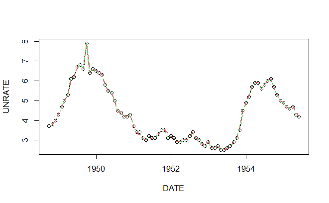

```r
bias.unemp[
  use.idx, lines(DATE, impute.sp.lookahead, col = 3, lwd = 2, lty = 3)
]
```

```r
# sem lookhead utilizer o rollapply
na_approx_no_lookahead <- function(x) {
  for (i in seq_along(x)) {
    if (is.na(x[i])) {
      # Interpolação apenas até o índice atual
      x[1:i] <- na.approx(x[1:i], na.rm = FALSE)
    }
  }
  return(x)
}
```

Utilizar quando:

1. Há tendencias

Quando não utilizar

1. Quando não tem tendencias

#### Comparação

| impute.ff | impute.rm.nolookahead | complete.rm | impute.li.lookahead | impute.sp.lookahead |
| --- | --- | --- | --- | --- |
| 0.003613744 | 0.004869514 | 0.00133452 | 0.001324381 | 0.00239141 |

### Suavização de dados

Não é raro antes de analisar, suavizar os dados. Sobre tudo quando se trata de visualizações que tem como objetivo contar um historia compreensivel sobre os dados.

#### Por que está suavizandos?

1. Preparação dos dados
2. Geração de caracteristicas
3. Predição
4. Visualização